# Trivago Data Science Code Documentation

YutingHsiao

March 11, 2018

## Code Documentation

### Data formatting and transform characters to numerical

The first section is data evaluation, after reviewing data structure and formats, the categorical string data has been transform into quantative for analytical purpose.

#### Load data from .csv and transform text into meaningful figures

```r
source_ <- read.csv("~/Documents/source.csv", sep = ";", stringsAsFactors = F)
source_$locale <- gsub("L", "", source_$locale) # Remove char L from locale
source_$locale <- as.numeric(source_$locale)
source_$day_of_week <- as.character(source_$day_of_week)
require(plyr)
source_$day_of_week <- revalue(x = source_$day_of_week, c("Monday"=1, "Thursday"=4, "Saturday"=6, "Tuesday"=2, "Friday"=5, "Sunday"=7, "Wednesday"=3)) # Change day to numerical for analysis
source_$day_of_week <- as.numeric(source_$day_of_week)
```

#### Manipulation of data column path_id_set

There are total 33216 locations in this set, assuming the path_id_set is a click-stream like points collection, the number of locations been visited in a session and specific location points should associated with the predictive target: hits.

path_id_set is been aggregated and splitted into a vector, the occurance of locations as

```r
str <- paste(source_$path_id_set, collapse = ';')
str <- strsplit(str, ";")
head(table(str))
```

```
## str
##             0      1     10    100   1000
##   4889 898419    917     69     18      1
```

from above, there are 4889 sessions without visiting any location, which is unusual. Meanwhile, over 90% of overall has visited location 0. I decide to remove those record without location log, due to: 1. The duration of 90% of non-path records is 0 2. The distribution of session_duration of the rest 10% shows very high figures, which is unusual.

```r
source_$num_loc <- 0
source_[nchar(source_$path_id_set)<1,]$path_id_set <- NA
require(stringr)
# Add a new attribue as how many locations are been visited during a session
source_$num_loc <- ifelse(nchar(source_$path_id_set)>0, str_count(source_$path_id_set, ";")+1, 0)

tmp <- source_[is.na(source_$num_loc),]
nrow(tmp)
[1] 4889
nrow(tmp[tmp$session_durantion > 0,])
[1] 598
summary(as.numeric(tmp[tmp$session_durantion > 0,]$session_durantion))
    Min.  1st Qu.   Median     Mean  3rd Qu.     Max.
    1.00    10.25   239.00  7406.55  4101.75 82462.00

source_[is.na(source_$num_loc),]$num_loc <- 0 # Set non-path records' total location count as 0
```

These sessions are been removed due to not qualified web connections.

### Data Pre-process 1 : Formatting and cleaning

```r
tb1 <- as.data.frame(table(str)) # Remove non-path records
tb1 <- tb1[order(-tb1$Freq),]
paths <- as.character(tb1[1:10,]$str)
# Add new columns for top 10 frequent locations, the datatype is binary
# If a location is been visited during a session, insert 1, otherwise 0
for (i in paths){
  #  Sample regex pattern
  #  ifelse(grepl("38715|^38715;|;38715$|;38715;", source_$path_id_set), 1, 0)
  pattern <- paste0(i,"|^",i,";|;",i,"$|;",i,";")
  source_[, ncol(source_) + 1] <- ifelse(grepl(pattern, source_$path_id_set), 1, 0)
  names(source_)[ncol(source_)] <- paste0("p_", i)
}

# Remove outliers of continous variable
source_$session_durantion <- as.numeric(source_$session_durantion)
source_ <- source_[!is.na(source_$session_durantion),]
source_ <- source_[!source_$session_durantion %in% boxplot.stats(source_$session_durantion)$out,]
source_ <- source_[source_$session_durantion>0,]
# Rows contain NA and zero session_durantion are also been removed (identified as brocken connections)
```

#### A summary of formatted dataset

```
##     row_num           locale       day_of_week     hour_of_day
##  Min.   :     2   Min.   :1.000   Min.   :1.000   Min.   : 0.00
##  1st Qu.:247170   1st Qu.:3.000   1st Qu.:2.000   1st Qu.: 9.00
##  Median :494702   Median :3.000   Median :4.000   Median :15.00
##  Mean   :494544   Mean   :3.648   Mean   :3.854   Mean   :13.29
##  3rd Qu.:741898   3rd Qu.:5.000   3rd Qu.:6.000   3rd Qu.:19.00
##  Max.   :988680   Max.   :6.000   Max.   :7.000   Max.   :23.00
##     agent_id        entry_page   path_id_set         traffic_type
##  Min.   : 0.000   Min.   :2100   Length:730187      Min.   : 1.000
##  1st Qu.: 6.000   1st Qu.:2113   Class :character   1st Qu.: 1.000
##  Median : 9.000   Median :2113   Mode  :character   Median : 2.000
##  Mean   : 7.419   Mean   :2174                      Mean   : 2.807
##  3rd Qu.:10.000   3rd Qu.:2116                      3rd Qu.: 4.000
##  Max.   :15.000   Max.   :8101                      Max.   :10.000
##  session_durantion     hits              num_loc            p_0
##  Min.   :  1.0     Length:730187      Min.   : 1.000   Min.   :0.0000
##  1st Qu.:  6.0     Class :character   1st Qu.: 2.000   1st Qu.:1.0000
##  Median : 51.0     Mode  :character   Median : 2.000   Median :1.0000
##  Mean   :133.9                        Mean   : 2.067   Mean   :0.9745
##  3rd Qu.:188.0                        3rd Qu.: 2.000   3rd Qu.:1.0000
##  Max.   :809.0                        Max.   :29.000   Max.   :1.0000
##     p_38715           p_34741           p_34812           p_34390
##  Min.   :0.00000   Min.   :0.00000   Min.   :0.00000   Min.   :0.00000
##  1st Qu.:0.00000   1st Qu.:0.00000   1st Qu.:0.00000   1st Qu.:0.00000
##  Median :0.00000   Median :0.00000   Median :0.00000   Median :0.00000
##  Mean   :0.02076   Mean   :0.01632   Mean   :0.01493   Mean   :0.00921
##  3rd Qu.:0.00000   3rd Qu.:0.00000   3rd Qu.:0.00000   3rd Qu.:0.00000
##  Max.   :1.00000   Max.   :1.00000   Max.   :1.00000   Max.   :1.00000
##     p_78506            p_34227             p_8514          p_31490
##  Min.   :0.000000   Min.   :0.000000   Min.   :0.0000   Min.   :0.000000
##  1st Qu.:0.000000   1st Qu.:0.000000   1st Qu.:0.0000   1st Qu.:0.000000
##  Median :0.000000   Median :0.000000   Median :0.0000   Median :0.000000
##  Mean   :0.008314   Mean   :0.008468   Mean   :0.0099   Mean   :0.007784
##  3rd Qu.:0.000000   3rd Qu.:0.000000   3rd Qu.:0.0000   3rd Qu.:0.000000
##  Max.   :1.000000   Max.   :1.000000   Max.   :1.0000   Max.   :1.000000
##     p_31965
##  Min.   :0.000000
##  1st Qu.:0.000000
##  Median :0.000000
##  Mean   :0.007557
##  3rd Qu.:0.000000
##  Max.   :1.000000
```

### Data Pre-process 2 : Scaling features into 0:1, transform skewed session_durantion to a better distribution by applying log().

```r
range01 <- function(x){(x-min(x))/(max(x)-min(x))} # Scaling function

source_$locale <- range01(source_$locale)
source_$day_of_week <- range01(source_$day_of_week)
source_$hour_of_day <- range01(source_$hour_of_day)
source_$agent_id <- range01(source_$agent_id)
source_$traffic_type <- range01(source_$traffic_type)
source_$session_durantion <- log(source_$session_durantion) # Log transformation of skewed  session_durantion
source_$session_durantion <- range01(source_$session_durantion)
source_$num_loc <- range01(source_$num_loc)
source_$hits <- as.numeric(source_$hits)

# Replace entry page with continous values
entry_id <- 1:length(unique(source_$entry_page))
names(entry_id) <- unique(source_$entry_page)[order(unique(source_$entry_page))]
source_$entry_id <- entry_id[as.character(source_$entry_page)]
source_$entry_page <- range01(source_$entry_id)
```

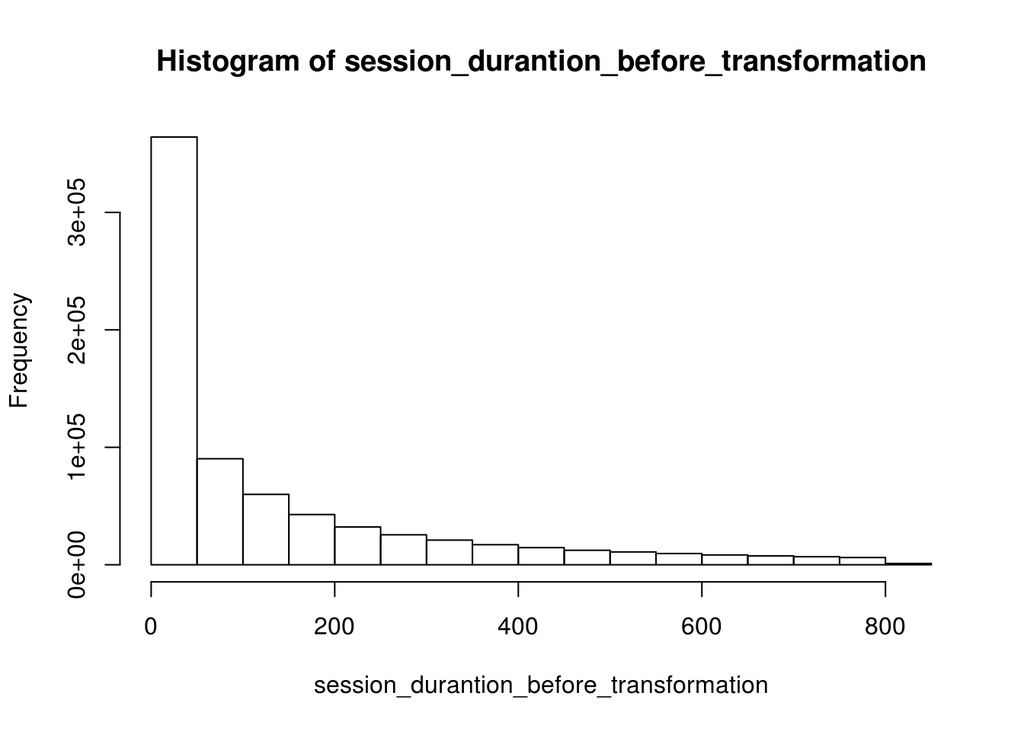

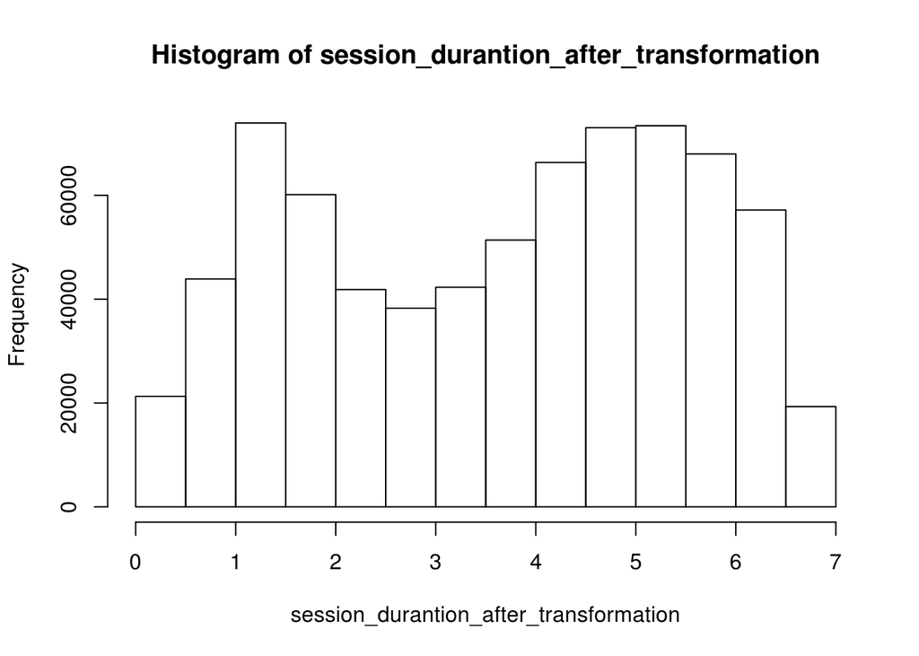

### Data Pre-process 3 : Split dataset and process target (hits)

```r
data_ <- source_[!is.na(source_$hits),-c(7, ncol(source_))] # Remove attributes as type character
pred_set <- source_[is.na(source_$hits),-c(7, ncol(source_))] # Split prection set (without hits value)
data_ <- data_[!data_$hits %in% boxplot.stats(data_$hits)$out,]
```

```
#> min(data_$hits)
```

```r
#[1] 2
```

```
#> max(data_$hits)
```

```r
#[1] 34
```

### Feature extraction

```r
library(corrplot)
corrplot(cor(data_[,-1]))
cor_marix <- cor(data_[,-1])
pca <- prcomp(data_[,-1], center = TRUE, scale = TRUE)
biplot(pca,  xlabs = rep("", nrow(data_[,-1])))

### Remove unnecessary & low-impacted columns and get training data ready
data_ready <- data_[,-c(2:4, (ncol(data_)-8):ncol(data_))]
pred_ready <- pred_set_[,-c(2:4, (ncol(pred_set_)-8):ncol(pred_set_))]
pred_ready$hits <- 0
```

#### Correlation matrix

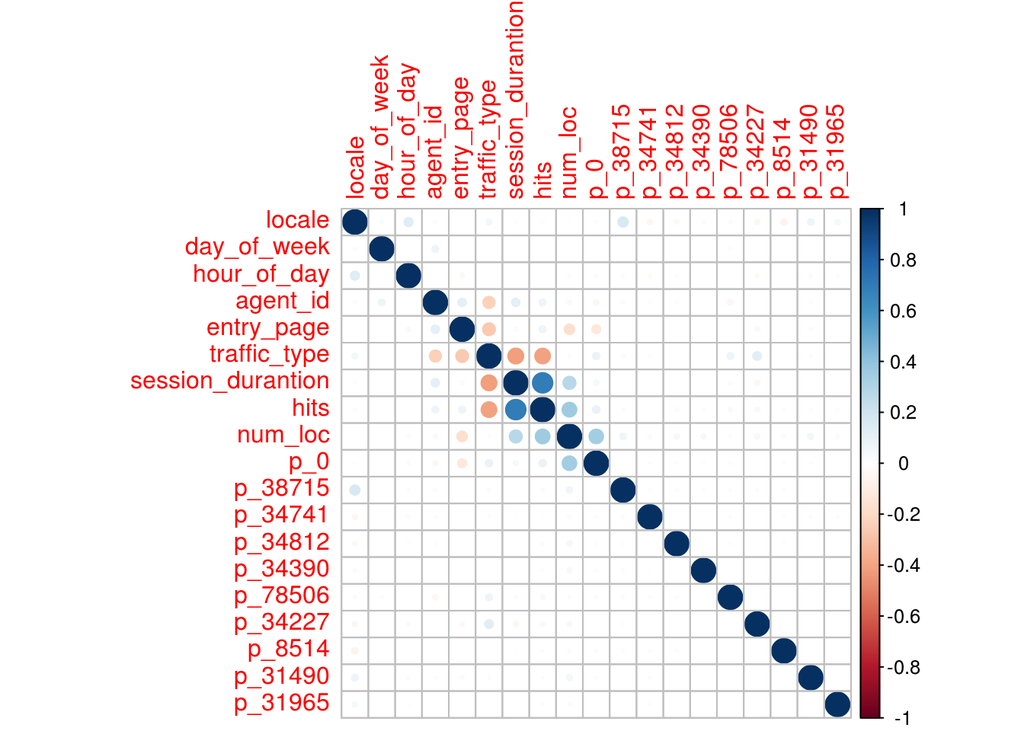

#### A plot of PCA result

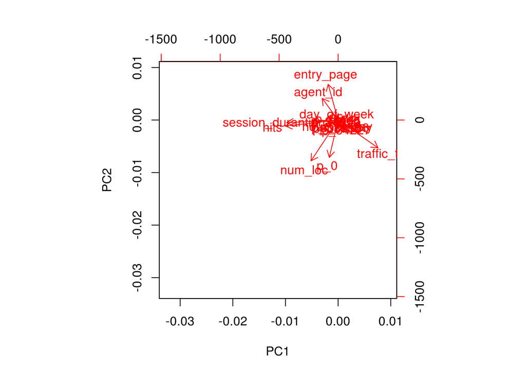

### Sample of processed dataset for training

|  | row_num | agent_id | entry_page | traffic_type | session_durantion | hits | num_loc | p_0 |
| --- | --- | --- | --- | --- | --- | --- | --- | --- |
| 2 | 988680 | 0.6666667 | 0.0152672 | 0.1111111 | 0.5812332 | 14 | 0.0357143 | 1 |
| 5 | 988677 | 0.6666667 | 0.0381679 | 0.0000000 | 0.1035197 | 3 | 0.0357143 | 1 |
| 8 | 988674 | 0.0666667 | 0.0152672 | 0.5555556 | 0.1035197 | 3 | 0.0357143 | 1 |
| 9 | 988673 | 0.6666667 | 0.0076336 | 0.5555556 | 0.2070394 | 3 | 0.0357143 | 1 |
| 12 | 988670 | 0.6000000 | 0.0152672 | 0.1111111 | 0.7678940 | 15 | 0.0357143 | 1 |
| 13 | 988669 | 0.5333333 | 0.0152672 | 0.1111111 | 0.7978636 | 24 | 0.0357143 | 1 |

### Support Vector Machine

```r
library(e1071)
RMSE <- vector()
for(i in 1:10){ # 10 fold
  set.seed(round(runif(1, 1, 10000)))
  smp <- sample(c(0,1), nrow(data_ready), c(.3, .7), replace = T) # Split data to 30% sample testing, 70% training
  train_set <- data_ready[smp == 1,-1]
  test_set <- data_ready[smp == 0,-1]
  model_svm <- svm(hits ~ . , train_set)
  assign(paste0("model_", model_svm)) # Save trained models
  pred <- predict(model_svm, test_set) # Make prediction
  assign(paste0("pred_", i))
  err <- test_set$hits - pred
  RMSE <- c(RMSE, sqrt(mean(err^2)))
}
```

#### 10-fold C.V.

> RMSE [1] 4.925165 4.936650 4.870721 4.900076 4.910934 4.882775 4.898672 4.885214 4.907764 4.916612

### Predict hits valus by using model_6

```r
p_ <- predict(model_6, pred_ready[,-1])
pred_ready$hits <- p_
```

#### The result of prediction as below

|  | row_num | locale | day_of_week | hour_of_day | agent_id | entry_page | path_id_set | traffic_type | session_durantion | hits |
| --- | --- | --- | --- | --- | --- | --- | --- | --- | --- | --- |
| 17 | 988665 | L4 | Sunday | 16 | 10 | 2113 | 79148;0 | 4 | 5 | 3 |
| 19 | 988663 | L3 | Friday | 20 | 10 | 2111 | 34287;0;60579 | 2 | 117 | 18 |
| 21 | 988661 | L2 | Friday | 19 | 10 | 2113 | 46575;0 | 2 | 80 | 10 |
| 22 | 988660 | L2 | Thursday | 20 | 1 | 2111 | 31467;0 | 2 | 26 | 7 |
| 28 | 988654 | L6 | Saturday | 15 | 6 | 2100 | 0;95235 | 1 | 44 | 10 |
| 38 | 988644 | L3 | Friday | 20 | 1 | 2113 | 34741;0 | 6 | 2 | 4 |

### Appendix: Pyhton tensorflow for training Neural Networks

```r
import tensorflow as tf
import matplotlib.pyplot as plt
import numpy as np
from numpy import genfromtxt
import pandas as pd
import math

train = genfromtxt("/content/trivago/data_ready.csv", delimiter=',')
train = np.delete(train, 0, 0)
train = np.delete(train, 0, 1)

x = train[:,0:6];x

y = train[:,6][:, np.newaxis];y
LR = 0.02
batchz = 1000
epoch = 100
datapoints = len(y)
steps = 10000

tf_x = tf.placeholder(tf.float32, x.shape)     # input x holder
tf_y = tf.placeholder(tf.float32, y.shape)

# Network layers
L = tf.layers.dense(tf_x, 6, tf.nn.relu)
L = tf.layers.dense(tf_x, 4, tf.nn.relu)
L = tf.layers.dense(L, 2, tf.nn.relu)
output = tf.layers.dense(L, 1)                     # output layer

loss = tf.losses.mean_squared_error(tf_y, output)   # compute cost
optimizer = tf.train.GradientDescentOptimizer(learning_rate=LR)
train_op = optimizer.minimize(loss)

saver = tf.train.Saver()

with tf.Session() as sess:
    sess.run(tf.global_variables_initializer())
    for step in range(steps):
        # train and net output
        _, loss_, pred = sess.run([train_op, loss, output], {tf_x: x, tf_y: y})
        if step % batchz == 0:
            print("step: {}, RMSE: {}".format(step, math.sqrt(loss_)))

    test = sess.run(output, {tf_x: x})
    save_model = saver.save(sess, "/content/dat/model.ckpt")
    test_hits = pd.DataFrame(test)
    print("Summary of predicted hits")
    print(test_hits.describe())
```

### Training result

```r
step: 0, RMSE: 12.874874
step: 1000, RMSE: 6.834079
step: 2000, RMSE: 5.838896
step: 3000, RMSE: 5.255543
step: 4000, RMSE: 5.153911
step: 5000, RMSE: 5.115760
step: 6000, RMSE: 5.094140
step: 7000, RMSE: 5.077186
step: 8000, RMSE: 5.062540
step: 9000, RMSE: 5.050345

Summary of predicted hits

count  416174.000000
mean        9.330908
std         5.758918
min         1.014817
25%         3.872907
50%         8.058168
75%        14.373281
max        25.231972
```